# Exam Preperation

```r
rm(list = ls())
```

This document will aim to Implement all the key processes identified throught the chapters labs and tutorial questions and solutions as defined in the book but applied onto the 2018 test sets and questions. we dont know exactly what these questions are but we do have an idea of the general topics examined so we can dig into these on these spesific datasets for practices and to get all the equations down pat.

#Section A

The data for this question concerns the accident rate and a number of variables relating to highway infrastructure for 39 sections of highways in the state of Minesota, 1973. The aim of the study was to inform the design of safer highway infrastructure. The data are adapted from the `alr3' R-package to reect useful transformations of the variables of interest and is provided in the`Question_1_Data.txt` le

This question is mainly examined with linear regression analysis with all dierent types of variables selection methods.

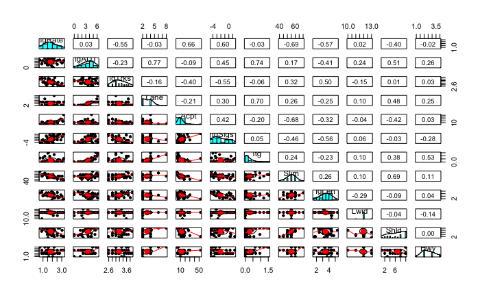

```r
#Read data in
RoadData <- read.csv("Question_1_Data.txt", sep = " ")
library(psych)
pairs.panels(RoadData)
```

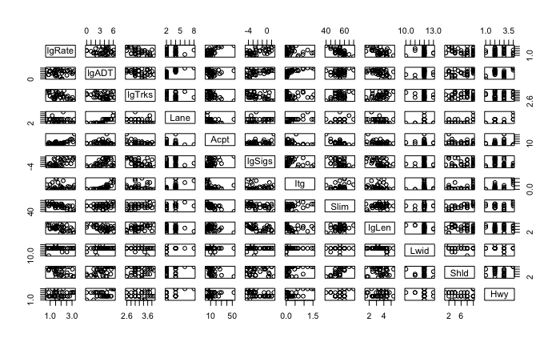

```r
pairs(RoadData)
```

```r
sapply(RoadData,class)
```

```
   lgRate     lgADT    lgTrks      Lane      Acpt    lgSigs       Itg      Slim     lgLen      Lwid      Shld       Hwy
"numeric" "numeric" "numeric" "integer" "numeric" "numeric" "numeric" "integer" "numeric" "integer" "integer"  "factor"
```

Split data up and do basic linear model

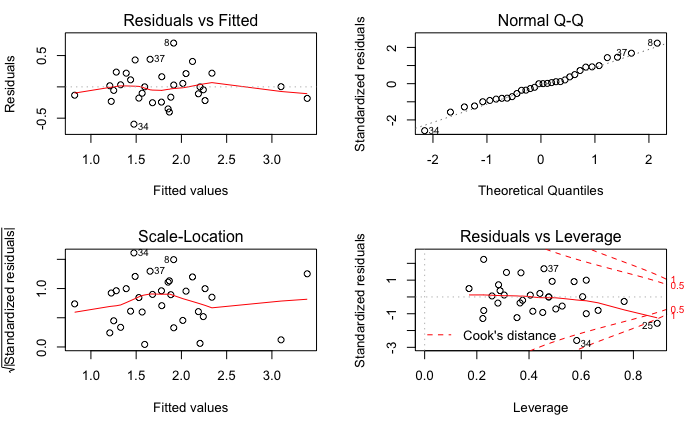

```r
train <- sample(seq_len(nrow(RoadData)), size = ceiling(dim(RoadData)[1]*0.8))
Roads.train <- RoadData[train, ]
Roads.test <- RoadData[-train, ]
#fit the linear model to the set and plot the output
#interactions: *. exponents (higher order) I(var)^2
lm.fit <- lm(lgRate ~ ., data = RoadData, subset = train)
par(mfrow = c(2, 2))
plot(lm.fit)
```

```r
summary(lm.fit)
```

```
Call:
lm(formula = lgRate ~ ., data = RoadData, subset = train)

Residuals:
     Min       1Q   Median       3Q      Max
-0.59560 -0.18066 -0.00024  0.17449  0.69928

Coefficients:
              Estimate Std. Error t value Pr(>|t|)
(Intercept)   7.532369   2.805226   2.685   0.0151 *
lgADT        -0.136851   0.123133  -1.111   0.2810
lgTrks       -0.227851   0.263530  -0.865   0.3986
Lane          0.022378   0.084993   0.263   0.7953
Acpt          0.001299   0.012964   0.100   0.9213
lgSigs        0.143498   0.091365   1.571   0.1337
Itg           0.056554   0.351727   0.161   0.8741
Slim         -0.033864   0.025587  -1.323   0.2022
lgLen        -0.273150   0.107365  -2.544   0.0203 *
Lwid         -0.088346   0.210668  -0.419   0.6799
Shld         -0.037379   0.053492  -0.699   0.4936
HwyMajor     -0.330127   0.399504  -0.826   0.4194
HwyOther     -0.344359   0.341946  -1.007   0.3273
HwyPrincipal  0.238904   0.565949   0.422   0.6779
---
Signif. codes:  0 ‘***’ 0.001 ‘**’ 0.01 ‘*’ 0.05 ‘.’ 0.1 ‘ ’ 1

Residual standard error: 0.3557 on 18 degrees of freedom
Multiple R-squared:  0.7912,    Adjusted R-squared:  0.6404
F-statistic: 5.246 on 13 and 18 DF,  p-value: 0.0007756
```

```r
#use the linear model to predict the output and compare this to the test set
pred.lm <- predict(lm.fit, Roads.test)
MSE <- mean((pred.lm - Roads.test$lgRate)^2)
sprintf("Test MSE for basic linear model: %s", MSE)
```

```
[1] "Test MSE for basic linear model: 0.285241710873398"
```

Variable selection methods

Could also include: `scope = list(upper=medv~.^3,lower = medv ~ 1)`

```r
#we can look at including all posible interaction terms within the linear model and then identifying the one with the lowest error
lm.fit.stepped <- step(lm.fit, direction= "both", steps = 1000, trace=FALSE)
summary(lm.fit.stepped)
```

```
Call:
lm(formula = lgRate ~ lgADT + lgSigs + Slim + lgLen + Hwy, data = RoadData,
    subset = train)

Residuals:
     Min       1Q   Median       3Q      Max
-0.67871 -0.15841 -0.02068  0.11801  0.64826

Coefficients:
             Estimate Std. Error t value Pr(>|t|)
(Intercept)   6.26927    0.76382   8.208    2e-08 ***
lgADT        -0.14475    0.08470  -1.709  0.10037
lgSigs        0.18486    0.06403   2.887  0.00810 **
Slim         -0.04413    0.01473  -2.997  0.00626 **
lgLen        -0.26200    0.08455  -3.099  0.00490 **
HwyMajor     -0.42888    0.31254  -1.372  0.18268
HwyOther     -0.28619    0.27223  -1.051  0.30360
HwyPrincipal  0.28470    0.46211   0.616  0.54364
---
Signif. codes:  0 ‘***’ 0.001 ‘**’ 0.01 ‘*’ 0.05 ‘.’ 0.1 ‘ ’ 1

Residual standard error: 0.3187 on 24 degrees of freedom
Multiple R-squared:  0.7764,    Adjusted R-squared:  0.7112
F-statistic: 11.91 on 7 and 24 DF,  p-value: 1.841e-06
```

```r
#use this output and compare to the test set
pred.lm <- predict(lm.fit.stepped, Roads.test)
MSE <- mean((pred.lm - Roads.test$lgRate)^2)
sprintf("Test MSE for stepped linear model: %s", MSE)
```

```
[1] "Test MSE for stepped linear model: 0.244392435358369"
```

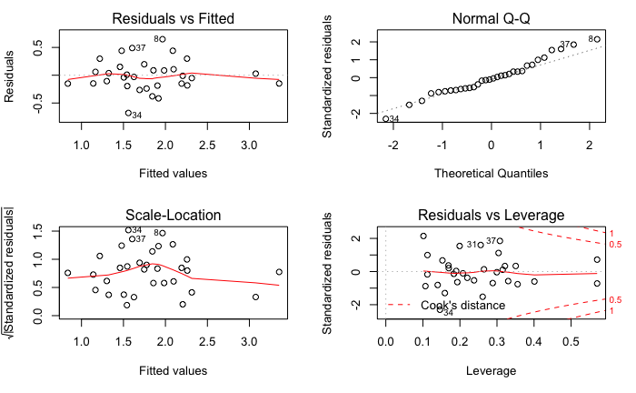

```r
par(mfrow = c(2, 2))
plot(lm.fit.stepped)
```

Stepped AIC

```r
library(MASS)
step <- stepAIC(lm.fit,trace=FALSE, direction= "both")
summary(step)
```

```
Call:
lm(formula = lgRate ~ lgADT + lgSigs + Slim + lgLen + Hwy, data = RoadData,
    subset = train)

Residuals:
     Min       1Q   Median       3Q      Max
-0.67871 -0.15841 -0.02068  0.11801  0.64826

Coefficients:
             Estimate Std. Error t value Pr(>|t|)
(Intercept)   6.26927    0.76382   8.208    2e-08 ***
lgADT        -0.14475    0.08470  -1.709  0.10037
lgSigs        0.18486    0.06403   2.887  0.00810 **
Slim         -0.04413    0.01473  -2.997  0.00626 **
lgLen        -0.26200    0.08455  -3.099  0.00490 **
HwyMajor     -0.42888    0.31254  -1.372  0.18268
HwyOther     -0.28619    0.27223  -1.051  0.30360
HwyPrincipal  0.28470    0.46211   0.616  0.54364
---
Signif. codes:  0 ‘***’ 0.001 ‘**’ 0.01 ‘*’ 0.05 ‘.’ 0.1 ‘ ’ 1

Residual standard error: 0.3187 on 24 degrees of freedom
Multiple R-squared:  0.7764,    Adjusted R-squared:  0.7112
F-statistic: 11.91 on 7 and 24 DF,  p-value: 1.841e-06
```

```r
step$anova
```

```
Stepwise Model Path
Analysis of Deviance Table

Initial Model:
lgRate ~ lgADT + lgTrks + Lane + Acpt + lgSigs + Itg + Slim +
    lgLen + Lwid + Shld + Hwy

Final Model:
lgRate ~ lgADT + lgSigs + Slim + lgLen + Hwy

      Step Df    Deviance Resid. Df Resid. Dev       AIC
1                                18   2.276986 -56.57227
2   - Acpt  1 0.001270851        19   2.278257 -58.55441
3    - Itg  1 0.003045610        20   2.281302 -60.51166
4   - Lane  1 0.010286303        21   2.291589 -62.36770
5   - Lwid  1 0.030737038        22   2.322326 -63.94134
6   - Shld  1 0.042459447        23   2.364785 -65.36156
7 - lgTrks  1 0.072895134        24   2.437680 -66.39005
```

```r
pred.lm <- predict(step, Roads.test)
MSE <- mean((pred.lm - Roads.test$lgRate)^2)
sprintf("Test MSE for stepped linear model: %s", MSE)
```

```
[1] "Test MSE for stepped linear model: 0.244392435358369"
```

Lasso

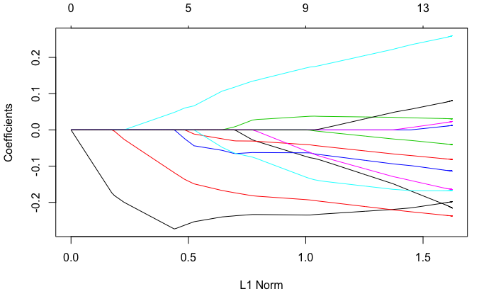

```r
library(glmnet)
#create a matrix & vector to store the input parameters
x <- model.matrix(lgRate ~ . , RoadData)[, -1]
x <- scale(x)
y <- RoadData$lgRate
#store all lambda values to test against
grid <- 10^seq(10, -5, length = 1000)
#run the lasso. alpha = 1 for lasso, alpha = 0 for ridge.
lasso.mod <- glmnet(x[train, ], y[train], alpha = 1, lambda = grid, standardize=FALSE)
plot(lasso.mod)
```

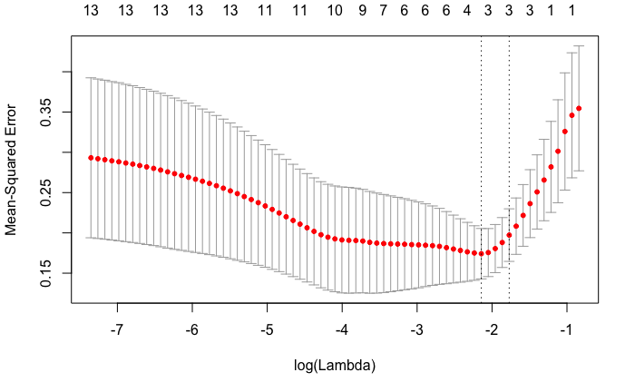

```r
#preform the cross validation
set.seed(42)
cv.out <- cv.glmnet(x[train, ], y[train], alpha = 1)
plot(cv.out)
```

```r
#we can now select the lowest lambda and use this to predict the output
bestlambda <- cv.out$lambda.min
#cross validated error
sprintf("Train cross validation error MSE for ideal Lasso model: %s", min(cv.out$cvm))
```

```
[1] "Train cross validation error MSE for ideal Lasso model: 0.174183321173874"
```

```r
#training error
lasso.pred <- predict(lasso.mod, s = bestlambda, newx = x[train, ])
MSE <- mean((lasso.pred - y[train])^2)
sprintf("Train MSE for ideal Lasso model: %s", MSE)
```

```
[1] "Train MSE for ideal Lasso model: 0.133005654054371"
```

```r
lasso.pred <- predict(lasso.mod, s = bestlambda, newx = x[-train, ])
MSE <- mean((lasso.pred - y[-train])^2)
sprintf("Test MSE for ideal Lasso model: %s", MSE)
```

```
[1] "Test MSE for ideal Lasso model: 0.499340964261604"
```

Next we’ll do some more generic variable selection and other processes to show other relevent techniques. `regsubsets()` function to perform best subset selection in order to choose the best model containing the predictors . What is the best model obtained according to $C_p$, BIC & adjusted $R^2$.

```r
set.seed(1)
x <- rnorm(100)
eps <- rnorm(100)
b0 <- 2
b1 <- 3
b2 <- -1
b3 <- 0.5
y <- b0 + b1 * x + b2 * x^2 + b3 * x^3 + eps
library(leaps)
data.full <- data.frame(y = y, x = x)
regfit.full <- regsubsets(y ~ x + I(x^2) + I(x^3) + I(x^4) + I(x^5) + I(x^6) + I(x^7) + I(x^8) + I(x^9) + I(x^10), data = data.full, nvmax = 10, method = "exhaustive")
reg.summary <- summary(regfit.full)
par(mfrow = c(2, 2))
plot(reg.summary$cp, xlab = "Number of variables", ylab = "C_p", pch = 19, type = "b")
points(which.min(reg.summary$cp), reg.summary$cp[which.min(reg.summary$cp)], col = "red", cex = 2, pch = 20)
```

```r
plot(reg.summary$bic, xlab = "Number of variables", ylab = "BIC", type = "l")
points(which.min(reg.summary$bic), reg.summary$bic[which.min(reg.summary$bic)], col = "red", cex = 2, pch = 20)
```

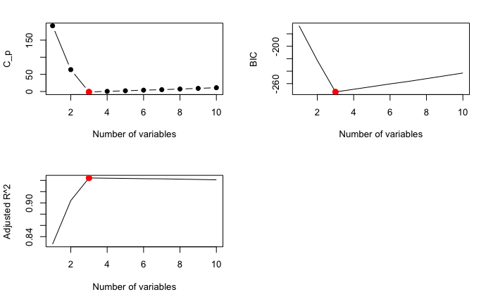

```r
plot(reg.summary$adjr2, xlab = "Number of variables", ylab = "Adjusted R^2", type = "l")
points(which.max(reg.summary$adjr2), reg.summary$adjr2[which.max(reg.summary$adjr2)], col = "re d", cex = 2, pch = 20)
```

```r
coef(regfit.full, which.max(reg.summary$adjr2))
```

```
(Intercept)           x      I(x^2)      I(x^5)
 2.07219472  3.44514720 -1.15676236  0.09022577
```

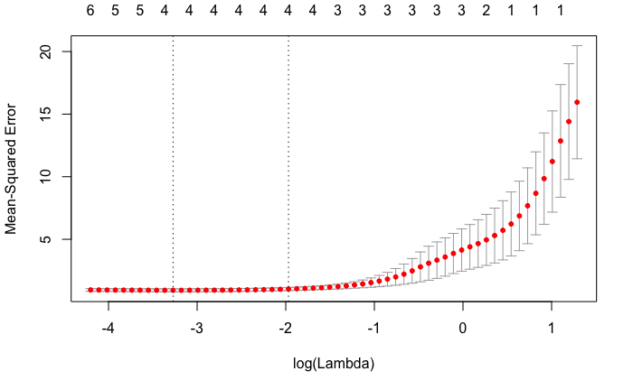

```r
xmat <- model.matrix(y ~ x + I(x^2) + I(x^3) + I(x^4) + I(x^5) + I(x^6) + I(x^7) + I(x^8) + I(x
^9) + I(x^10), data = data.full)[, -1]
cv.lasso <- cv.glmnet(xmat, y, alpha = 1)
plot(cv.lasso)
```

```r
bestlam <- cv.lasso$lambda.min
bestlam
```

```
[1] 0.03795616
```

```r
fit.lasso <- glmnet(xmat, y, alpha = 1)
predict(fit.lasso, s = bestlam, type = "coefficients")[1:11, ]
```

```
(Intercept)           x      I(x^2)      I(x^3)      I(x^4)      I(x^5)      I(x^6)      I(x^7)      I(x^8)      I(x^9)     I(x^10)
 2.04091434  3.28373245 -1.10646862  0.14042235  0.00000000  0.06399454  0.00000000  0.00000000  0.00000000  0.00000000  0.00000000
```

# Question 2

A short term insurer’s research and development department has developed a metric for use in detecting fraudulent claims. The metric consists of two scores, $α$ and $β$ calculated based on metadata from an internal claims logging system. Combining this with data from the internal claims investigation team, where the claims in question were evaluated and labelled according to whether or not they were in fact fraudulent, we assemble a dataset of ($α$,$β$)-scores and class labels for each pair of scores where Class = 1 corresponds to valid claim and Class = 2 to a fraudulent claim. Read the data in from `Question_2_Data.txt` and answer the questions that follow.

This question is mainly examined with logistic linear regression analysis and discriminant analysis with all different types of variables selection methods.

```r
full.data = read.table('Question_2_Data.txt', h = TRUE)
attach(full.data)
head(full.data, 7)
```

|  | Class | Alpha | Beta |
| --- | --- | --- | --- |
| 1 | 1 | 0.7233414 | -1.9742457 |
| 2 | 2 | -0.5188689 | 0.6043967 |
| 3 | 1 | 1.7378215 | -0.4071885 |
| 4 | 2 | 1.9059440 | 1.3583617 |
| 5 | 1 | 1.1954854 | -1.9829110 |
| 6 | 2 | 1.2942526 | 0.4909302 |
| 7 | 1 | -1.7006747 | 0.5111554 |

```r
full.data[,1] = as.factor(full.data[,1])
train <- sample(seq_len(nrow(full.data)), size = ceiling(dim(full.data)[1]*0.8)) #~80% of the set
Insurance.train <- full.data[train, ]
Insurance.test <- full.data[-train, ]
```

Basic logistic regression model first

```r
library(caret)
glm.fit <- glm(Class ~ ., data = Insurance.train, family = binomial())
probs <- predict(glm.fit, newdata = Insurance.test, type = "response")
glm.pred <- rep(1, length(probs))
glm.pred[probs > 0.5] <- 2
confusionMatrix(factor(glm.pred), Insurance.test$Class, mode = "everything")
```

```
Confusion Matrix and Statistics

          Reference
Prediction  1  2
         1 97  9
         2  1  8

               Accuracy : 0.913
                 95% CI : (0.8459, 0.9575)
    No Information Rate : 0.8522
    P-Value [Acc > NIR] : 0.03731

                  Kappa : 0.5715
 Mcnemar's Test P-Value : 0.02686

            Sensitivity : 0.9898
            Specificity : 0.4706
         Pos Pred Value : 0.9151
         Neg Pred Value : 0.8889
              Precision : 0.9151
                 Recall : 0.9898
                     F1 : 0.9510
             Prevalence : 0.8522
         Detection Rate : 0.8435
   Detection Prevalence : 0.9217
      Balanced Accuracy : 0.7302

       'Positive' Class : 1
```

```r
table(glm.pred, Insurance.test$Class)
```

```
glm.pred  1  2
       1 97  9
       2  1  8
```

```r
plot(probs, as.factor(glm.pred), col = (Insurance.test$Class != 1) +9, type="p", xlab="probability", ylab="Responce", yaxt="n")
grid()
```

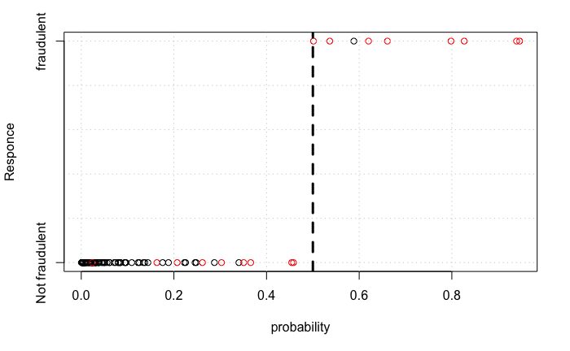

```r
abline(v=c(0.5), lty=2, lwd=3)
axis(2, at=1:2, labels=c('Not fraudulent','fraudulent'))
```

LDA

```r
library(MASS)
lda.fit <- lda(Class ~ ., data = Insurance.train)
lda.pred <- predict(lda.fit, newdata = Insurance.test)
confusionMatrix(lda.pred$class, Insurance.test$Class, mode = "everything")
```

```
Confusion Matrix and Statistics

          Reference
Prediction  1  2
         1 97  9
         2  1  8

               Accuracy : 0.913
                 95% CI : (0.8459, 0.9575)
    No Information Rate : 0.8522
    P-Value [Acc > NIR] : 0.03731

                  Kappa : 0.5715
 Mcnemar's Test P-Value : 0.02686

            Sensitivity : 0.9898
            Specificity : 0.4706
         Pos Pred Value : 0.9151
         Neg Pred Value : 0.8889
              Precision : 0.9151
                 Recall : 0.9898
                     F1 : 0.9510
             Prevalence : 0.8522
         Detection Rate : 0.8435
   Detection Prevalence : 0.9217
      Balanced Accuracy : 0.7302

       'Positive' Class : 1
```

KNN

```r
train.X <- as.matrix(Insurance.train[,-1])
train.Y <- as.matrix(Insurance.train[,1])
test.X <- as.matrix(Insurance.test[,-1])
library(class)
pred.knn <- knn(train.X, test.X, train.Y, k = 1)
confusionMatrix(pred.knn, Insurance.test$Class)
```

```
Confusion Matrix and Statistics

          Reference
Prediction  1  2
         1 95  7
         2  3 10

               Accuracy : 0.913
                 95% CI : (0.8459, 0.9575)
    No Information Rate : 0.8522
    P-Value [Acc > NIR] : 0.03731

                  Kappa : 0.6177
 Mcnemar's Test P-Value : 0.34278

            Sensitivity : 0.9694
            Specificity : 0.5882
         Pos Pred Value : 0.9314
         Neg Pred Value : 0.7692
             Prevalence : 0.8522
         Detection Rate : 0.8261
   Detection Prevalence : 0.8870
      Balanced Accuracy : 0.7788

       'Positive' Class : 1
```

```r
mean(pred.knn != Insurance.test$Class)
```

```
[1] 0.08695652
```

```r
library(klaR)
greedy.wilks(Class ~. ,Insurance.train, niveau = 0.15)
```

```
Formula containing included variables:

Class ~ Alpha
<environment: 0x13bed6280>


Values calculated in each step of the selection procedure:
```

| vars | Wilks.lambda | F.statistics.overall | p.value.overall | F.statistics.diff | p.value.diff |
| --- | --- | --- | --- | --- | --- |
| Alpha | 0.8286103 | 94.7327 | 1.786691e-20 | 94.7327 | 1.786691e-20 |

Selection is exactly the same as done in the regression case. we use the step function for forwards & backwards. use glmnet and cv.glmnet for logistic regression with lasso while adding standardize=TRUE and family = ‘binomial’.

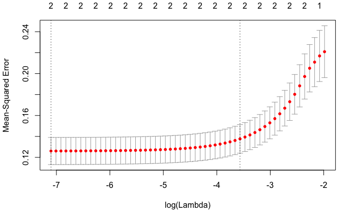

```r
glm.cv <- cv.glmnet(train.X, train.Y, nfolds = 10, type.measure = "mse", standardize=TRUE, family = 'binomial')
plot(glm.cv)
```

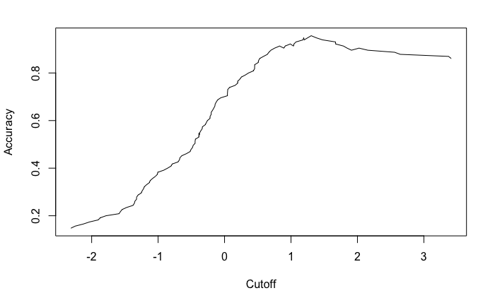

```r
library(ROCR)
pred_cv <- prediction(lda.pred$x, Insurance.test$Class)
acc = performance(pred_cv, "acc")
plot(acc)
```

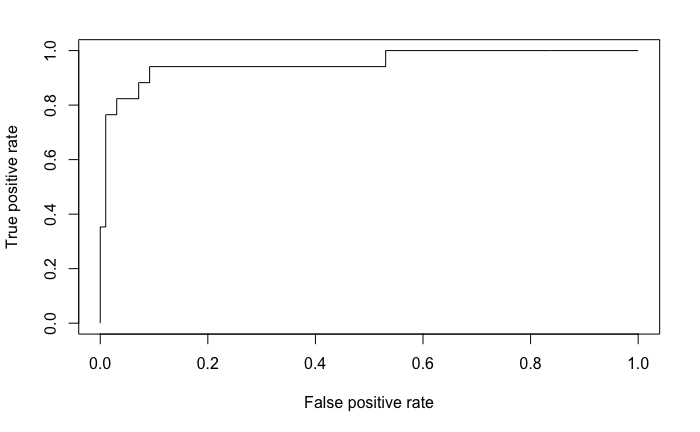

```r
roc = performance(pred_cv, "tpr", "fpr")
plot(roc)
```

```r
auc = performance(pred_cv, measure = "auc")@y.values
#plot(auc)
```

SECTION B

QUESTION 3

This data set includes descriptions of hypothetical samples corresponding to 23 species of gilled mushrooms in the Agaricus and Lepiota Family. Each species is identied as denitely edible, denitely poisonous, or of unknown edibility and therefore not recom- mended. This latter class was combined with the poisonous one. The Guide clearly states that there is no simple rule for determining the edibility of a mushroom; no rule like leaets three, let it be for Poisonous Oak and Ivy. As a Data Science Masters student, utilize the already existed database of the mushrooms to build a decision tree to assist the process of determining whether a mushroom is poisonous or not. The data is provided in the mushrooms.csv le. Read the data into R and answer the questions that follow in full.

This question is mainly examined with classication trees, bagging, random forests with all dierent types of variables selection methods and parameter tunings.

```r
mushrooms <- read.csv("mushrooms.csv")
set.seed(12345)
mushrooms <- mushrooms[sample(nrow(mushrooms)),]
mushrooms.train <- mushrooms[1:6500,]
mushrooms.test <- mushrooms[6501:nrow(mushrooms),]
```

```r
library(tree)
stopcrit <- tree.control(nobs=nrow(mushrooms.train), minsize = 1, mindev = 0)
treemodel = tree(poison ~ ., data = mushrooms.train, control = stopcrit, split="deviance")
treemodel
```

```
node), split, n, deviance, yval, (yprob)
      * denotes terminal node

 1) root 6500 9002.00 e ( 0.518308 0.481692 )
   2) odor: a,l,n 3467  892.20 e ( 0.971733 0.028267 )
     4) sporepcolor: b,h,k,n,o,u,w,y 3408  426.20 e ( 0.988556 0.011444 )
       8) scbelowring: e,g,o,p,w 3324  100.30 e ( 0.997894 0.002106 )
        16) habitat: d,g,m,p,u,w 3163    0.00 e ( 1.000000 0.000000 ) *
        17) habitat: l 161   57.59 e ( 0.956522 0.043478 )
          34) csurface: s 154    0.00 e ( 1.000000 0.000000 ) *
          35) csurface: g,y 7    0.00 p ( 0.000000 1.000000 ) *
       9) scbelowring: n,y 84  111.60 e ( 0.619048 0.380952 )
        18) stalkroot: b 52    0.00 e ( 1.000000 0.000000 ) *
        19) stalkroot: ?,c 32    0.00 p ( 0.000000 1.000000 ) *
     5) sporepcolor: r 59    0.00 p ( 0.000000 1.000000 ) *
   3) odor: c,f,m,p,s,y 3033    0.00 p ( 0.000000 1.000000 ) *
```

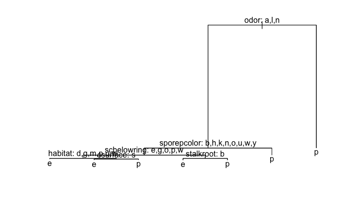

```r
plot(treemodel)
text(treemodel, pretty = 0)
```

```r
summary(treemodel)
```

```
Classification tree:
tree(formula = poison ~ ., data = mushrooms.train, control = stopcrit,
    split = "deviance")
Variables actually used in tree construction:
[1] "odor"        "sporepcolor" "scbelowring" "habitat"     "csurface"    "stalkroot"
Number of terminal nodes:  7
Residual mean deviance:  0 = 0 / 6493
Misclassification error rate: 0 = 0 / 6500
```

```r
probs <- predict(treemodel, newdata = mushrooms.test)
tree.pred <- rep('e', dim(probs)[1])
tree.pred[probs[,2]> 0.5] <- 'p'
tree.pred <- as.factor(tree.pred)
confusionMatrix(tree.pred, mushrooms.test$poison)
```

```
Confusion Matrix and Statistics

          Reference
Prediction   e   p
         e 839   0
         p   0 785

               Accuracy : 1
                 95% CI : (0.9977, 1)
    No Information Rate : 0.5166
    P-Value [Acc > NIR] : < 2.2e-16

                  Kappa : 1
 Mcnemar's Test P-Value : NA

            Sensitivity : 1.0000
            Specificity : 1.0000
         Pos Pred Value : 1.0000
         Neg Pred Value : 1.0000
             Prevalence : 0.5166
         Detection Rate : 0.5166
   Detection Prevalence : 0.5166
      Balanced Accuracy : 1.0000

       'Positive' Class : e
```

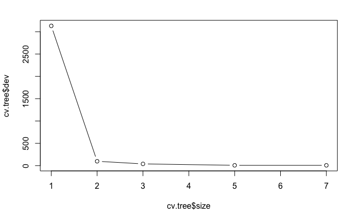

```r
cv.tree = cv.tree(treemodel,FUN=prune.misclass, K = 10)
plot(cv.tree$size ,cv.tree$dev ,type="b")
```

```r
best <- which.min(rev(cv.tree$dev))
prunedtree = prune.tree(treemodel, best)
summary(prunedtree)
```

```
Classification tree:
tree(formula = poison ~ ., data = mushrooms.train, control = stopcrit,
    split = "deviance")
Variables actually used in tree construction:
[1] "odor"        "sporepcolor" "scbelowring" "habitat"     "csurface"    "stalkroot"
Number of terminal nodes:  7
Residual mean deviance:  0 = 0 / 6493
Misclassification error rate: 0 = 0 / 6500
```

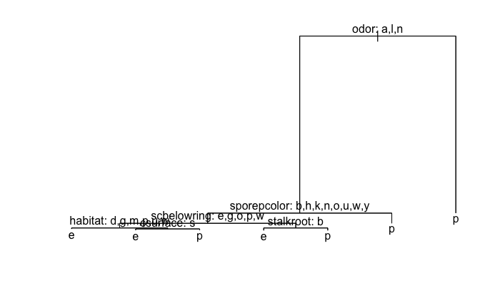

```r
plot(prunedtree)
text(treemodel, pretty = 0)
```

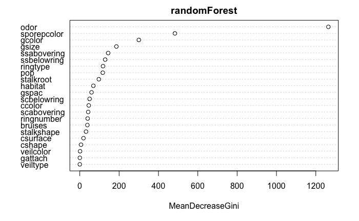

```r
# Bagging and Random Forests #### if mtry = number of predictors then we have bagging.
library(randomForest)
randomForest = randomForest(poison ~ ., data = mushrooms.train, mtry = 3, ntree = 100, importance = TRUE)
randomForest = randomForest(poison ~ ., data = mushrooms.train, mtry = sqrt(ncol(mushrooms.train)), ntree = 100, importance = TRUE)
varImpPlot(randomForest, type=2)
```

```r
# Boosting ####
library(gbm)
boosting <- gbm(poison ~ ., data = mushrooms.train, cv.folds = 10, distribution="gaussian")
```

```
variable 16: veiltype has no variation.
```

|  | var | rel.inf |
| --- | --- | --- |
| odor | odor | 94.39208399 |
| sporepcolor | sporepcolor | 4.22808989 |
| scbelowring | scbelowring | 1.20155314 |
| gsize | gsize | 0.10525351 |
| ssbelowring | ssbelowring | 0.07301947 |
| cshape | cshape | 0.00000000 |
| csurface | csurface | 0.00000000 |
| ccolor | ccolor | 0.00000000 |
| bruises | bruises | 0.00000000 |
| gattach | gattach | 0.00000000 |

[output cut: 12 more lines]

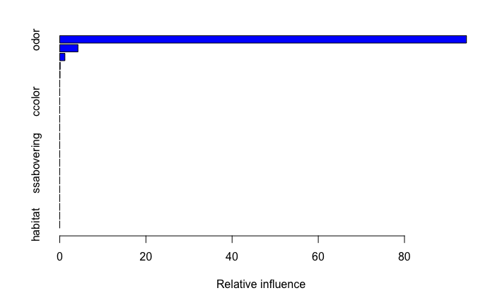

```r
summary(boosting)
```

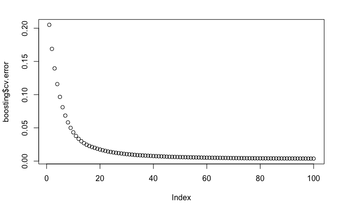

```r
plot(boosting$cv.error)
```

```r
library(h2o)
library(caret)
library(mlbench)
library(ggplot2)
library(reshape2)
library(DEEPR)
h2o.init()
```

[output not shown]

```
Your H2O cluster version is too old (5 months and 1 day)!
Please download and install the latest version from http://h2o.ai/download/
```

```r
rf.spam <- h2o.randomForest(
    training_frame = as.h2o(mushrooms.train),
    y = 1,
    seed = 1
  )
```

```
Dropping bad and constant columns: [veiltype].
```

```r
rf.probs <- h2o.predict(
  object = rf.spam,
  newdata = as.h2o(mushrooms.test)
)
rf.probs <- as.data.frame(rf.probs)
confusionMatrix(rf.probs$predict, mushrooms.test$poison, mode = "everything")
```

```
Confusion Matrix and Statistics

          Reference
Prediction   e   p
         e 839   0
         p   0 785

               Accuracy : 1
                 95% CI : (0.9977, 1)
    No Information Rate : 0.5166
    P-Value [Acc > NIR] : < 2.2e-16

                  Kappa : 1
 Mcnemar's Test P-Value : NA

            Sensitivity : 1.0000
            Specificity : 1.0000
         Pos Pred Value : 1.0000
         Neg Pred Value : 1.0000
              Precision : 1.0000
                 Recall : 1.0000
                     F1 : 1.0000
             Prevalence : 0.5166
         Detection Rate : 0.5166
   Detection Prevalence : 0.5166
      Balanced Accuracy : 1.0000

       'Positive' Class : e
```

```r
mtries <- floor(seq(floor(sqrt(length(mushrooms.train))/2),
              floor(sqrt(length(mushrooms.train))*3),
              length.out = 5))
ntrees = floor(seq(50, 300,length = 5)) #Number of trees
max_depth = seq(10, 50,length = 5) #Maximum tree depth
hyper_params <- list(mtries = mtries, ntrees = ntrees, max_depth = max_depth)
rf.grid <- h2o.grid(algorithm = "randomForest",
                      hyper_params = hyper_params,
                      x = 2:23,
                      y = 1,
                      training_frame = as.h2o(mushrooms.train),
                      nfolds = 0,
                      seed = 1)
rf.best <- h2o.getModel(rf.grid@model_ids[[1]])
#Validation results
rf.probs <- h2o.predict(
  object = rf.best,
  newdata = as.h2o(mushrooms.test)
)
rf.probs <- as.data.frame(rf.probs)
confusionMatrix(rf.probs$predict, mushrooms.test$poison, mode = "everything")
```

```
Confusion Matrix and Statistics

          Reference
Prediction   e   p
         e 839   0
         p   0 785

               Accuracy : 1
                 95% CI : (0.9977, 1)
    No Information Rate : 0.5166
    P-Value [Acc > NIR] : < 2.2e-16

                  Kappa : 1
 Mcnemar's Test P-Value : NA

            Sensitivity : 1.0000
            Specificity : 1.0000
         Pos Pred Value : 1.0000
         Neg Pred Value : 1.0000
              Precision : 1.0000
                 Recall : 1.0000
                     F1 : 1.0000
             Prevalence : 0.5166
         Detection Rate : 0.5166
   Detection Prevalence : 0.5166
      Balanced Accuracy : 1.0000

       'Positive' Class : e
```

Other good examples

```r
set.seed(1)
train <- sample(1:nrow(Boston), nrow(Boston) / 2)
Boston.train <- Boston[train, -14]
Boston.test <- Boston[-train, -14]
Y.train <- Boston[train, 14]
Y.test <- Boston[-train, 14]
rf.boston1 <- randomForest(Boston.train, y = Y.train, xtest = Boston.test, ytest = Y.test, mtry
= ncol(Boston) - 1, ntree = 500)
rf.boston2 <- randomForest(Boston.train, y = Y.train, xtest = Boston.test, ytest = Y.test, mtry
= (ncol(Boston) - 1) / 2, ntree = 500)
rf.boston3 <- randomForest(Boston.train, y = Y.train, xtest = Boston.test, ytest = Y.test, mtry
= sqrt(ncol(Boston) - 1), ntree = 500)
plot(1:500, rf.boston1$test$mse, col = "green", type = "l", xlab = "Number of Trees", ylab = "T
est MSE", ylim = c(10, 19))
lines(1:500, rf.boston2$test$mse, col = "red", type = "l")
```

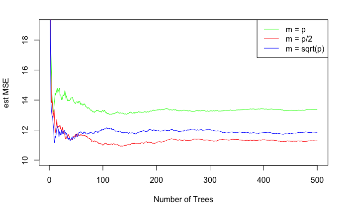

```r
lines(1:500, rf.boston3$test$mse, col = "blue", type = "l")
legend("topright", c("m = p", "m = p/2", "m = sqrt(p)"), col = c("green", "red", "blue"), cex =
1, lty = 1)
```

```r
library(ISLR)
set.seed(1)
train <- sample(1:nrow(Carseats), nrow(Carseats) / 2)
Carseats.train <- Carseats[train, ]
Carseats.test <- Carseats[-train, ]
tree.carseats <- tree(Sales ~ ., data = Carseats.train)
yhat <- predict(tree.carseats, newdata = Carseats.test)
mean((yhat - Carseats.test$Sales)^2)
```

```
[1] 4.148897
```

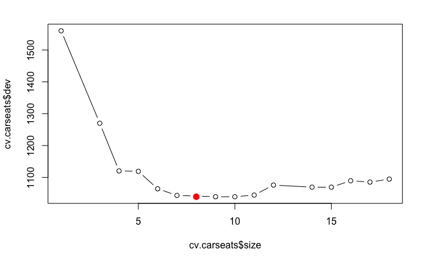

```r
cv.carseats <- cv.tree(tree.carseats)
plot(cv.carseats$size, cv.carseats$dev, type = "b")
tree.min <- which.min(cv.carseats$dev)
points(tree.min, cv.carseats$dev[tree.min], col = "red", cex = 2, pch = 20)
```

```r
bag.carseats <- randomForest(Sales ~ ., data = Carseats.train, mtry = 10, ntree = 500, importance = TRUE)
yhat.bag <- predict(bag.carseats, newdata = Carseats.test)
mean((yhat.bag - Carseats.test$Sales)^2)
```

```
[1] 2.633915
```

```r
importance(bag.carseats)
```

```
               %IncMSE IncNodePurity
CompPrice   16.9874366    126.852848
Income       3.8985402     78.314126
Advertising 16.5698586    123.702901
Population   0.6487058     62.328851
Price       55.3976775    514.654890
ShelveLoc   42.7849818    319.133777
Age         20.5135255    185.582077
Education    3.4615211     42.253410
Urban       -2.5125087      8.700009
US           7.3586645     18.180651
```

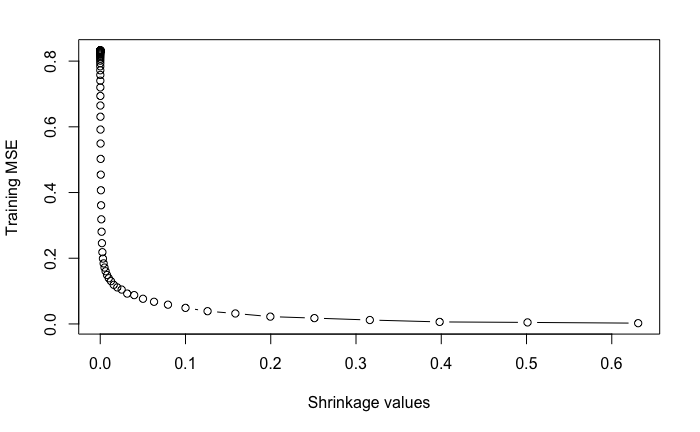

```r
Hitters <- na.omit(Hitters)
Hitters$Salary <- log(Hitters$Salary)
train <- 1:200
Hitters.train <- Hitters[train, ]
Hitters.test <- Hitters[-train, ]
library(gbm)
set.seed(1)
pows <- seq(-10, -0.2, by = 0.1)
lambdas <- 10^pows
train.err <- rep(NA, length(lambdas))
for (i in 1:length(lambdas)) {
    boost.hitters <- gbm(Salary ~ ., data = Hitters.train, distribution = "gaussian", n.trees = 1000, shrinkage = lambdas[i])
    pred.train <- predict(boost.hitters, Hitters.train, n.trees = 1000)
    train.err[i] <- mean((pred.train - Hitters.train$Salary)^2)
}
plot(lambdas, train.err, type = "b", xlab = "Shrinkage values", ylab = "Training MSE")
```

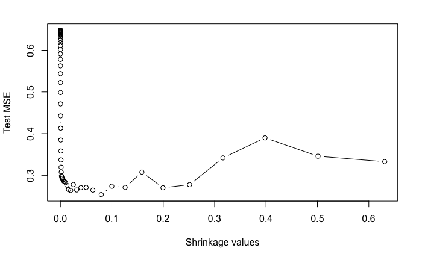

```r
set.seed(1)
test.err <- rep(NA, length(lambdas))
for (i in 1:length(lambdas)) {
    boost.hitters <- gbm(Salary ~ ., data = Hitters.train, distribution = "gaussian", n.trees = 1000, shrinkage = lambdas[i])
    yhat <- predict(boost.hitters, Hitters.test, n.trees = 1000)
    test.err[i] <- mean((yhat - Hitters.test$Salary)^2)
}
plot(lambdas, test.err, type = "b", xlab = "Shrinkage values", ylab = "Test MSE")
```

|  | var | rel.inf |
| --- | --- | --- |
| CAtBat | CAtBat | 20.8404970 |
| CRBI | CRBI | 12.3158959 |
| Walks | Walks | 7.4186037 |
| PutOuts | PutOuts | 7.1958539 |
| Years | Years | 6.3104535 |
| CWalks | CWalks | 6.0221656 |
| CHmRun | CHmRun | 5.7759763 |
| CHits | CHits | 4.8914360 |
| AtBat | AtBat | 4.2187460 |
| RBI | RBI | 4.0812410 |

[output cut: 9 more lines]

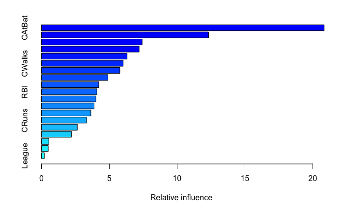

```r
library(gbm)
boost.hitters <- gbm(Salary ~ ., data = Hitters.train, distribution = "gaussian", n.trees = 1000, shrinkage = lambdas[which.min(test.err)])
summary(boost.hitters)
```

# QUESTION 4

For many years, scientists have questioned why so many Pima Indian Women suffer from diabetes in relation to other ethnicities. The diagnostic, binary-valued variable investigated is whether the patient shows signs of diabetes according to World Health Organization criteria (i.e., if the 2 hour post-load plasma glucose was at least 200 mg/dl at any survey examination or if found during routine medical care) or not. The population lives near Phoenix, Arizona, USA and a random sample of 768 females at least 21 years old of Pima Indian heritage was used to classify the females. The data is provided in the pimaDiabetes.csv.

This question is mainly examined with neural networks and support vector machines with all dierent types of variables selection methods and parameter tunings.

```r
pimaDiabetes <- read.csv("pimaDiabetes.csv")
set.seed(12345)
pimaDiabetes = pimaDiabetes[sample(nrow(pimaDiabetes)),]
pimaDiabetes$testDiabetes = as.factor(pimaDiabetes$testDiabetes)
class(pimaDiabetes$testDiabetes)
```

```
[1] "factor"
```

```r
pimaDiabetes.train <- pimaDiabetes[1:700,]
pimaDiabetes.test <- pimaDiabetes[701:nrow(pimaDiabetes),]
```

lets start with SVMs

```r
suppressMessages(library(e1071))
simple.svm <- svm(testDiabetes~.,
                  data = pimaDiabetes.train,
                  kernel = "polynomial",
                  gamma = 1,
                  cost = 1)
#simple.svm$index support vectors
svm.pred <- predict(simple.svm, pimaDiabetes.test)
confusionMatrix(svm.pred, pimaDiabetes.test$testDiabetes)
```

```
Confusion Matrix and Statistics

          Reference
Prediction  0  1
         0 26 18
         1  6 18

               Accuracy : 0.6471
                 95% CI : (0.5217, 0.7592)
    No Information Rate : 0.5294
    P-Value [Acc > NIR] : 0.03339

                  Kappa : 0.3061
 Mcnemar's Test P-Value : 0.02474

            Sensitivity : 0.8125
            Specificity : 0.5000
         Pos Pred Value : 0.5909
         Neg Pred Value : 0.7500
             Prevalence : 0.4706
         Detection Rate : 0.3824
   Detection Prevalence : 0.6471
      Balanced Accuracy : 0.6562

       'Positive' Class : 0
```

```r
tune.out <- tune(svm, testDiabetes~., data = pimaDiabetes.train, kernel = "polynomial",
                 ranges = list(gamma = c(2^-13,2^-2), cost = c(2^-0,2^13)))
```

[output not shown]

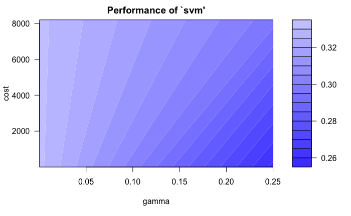

```r
plot(tune.out)
```

```r
summary(tune.out)
```

```
Parameter tuning of ‘svm’:

- sampling method: 10-fold cross validation

- best parameters:
```

|  | gamma | cost |
| --- | --- | --- |
|  | 0.25 | 1 |

```
- best performance: 0.2585714

- Detailed performance results:
```

| gamma | cost | error | dispersion |
| --- | --- | --- | --- |
| 0.0001220703 | 1 | 0.3314286 | 0.05207704 |
| 0.2500000000 | 1 | 0.2585714 | 0.06715805 |
| 0.0001220703 | 8192 | 0.3314286 | 0.05207704 |
| 0.2500000000 | 8192 | 0.2971429 | 0.05379056 |

```r
best.model <- tune.out$best.model
yhat_test <- predict(best.model, pimaDiabetes.test)
confusionMatrix(yhat_test, pimaDiabetes.test$testDiabetes)
```

```
Confusion Matrix and Statistics

          Reference
Prediction  0  1
         0 30 15
         1  2 21

               Accuracy : 0.75
                 95% CI : (0.6302, 0.8471)
    No Information Rate : 0.5294
    P-Value [Acc > NIR] : 0.0001551

                  Kappa : 0.5093
 Mcnemar's Test P-Value : 0.0036093

            Sensitivity : 0.9375
            Specificity : 0.5833
         Pos Pred Value : 0.6667
         Neg Pred Value : 0.9130
             Prevalence : 0.4706
         Detection Rate : 0.4412
   Detection Prevalence : 0.6618
      Balanced Accuracy : 0.7604

       'Positive' Class : 0
```

lastly…Nerual networks!!!

```r
h2o.init()
```

[output not shown]

```
Your H2O cluster version is too old (5 months and 1 day)!
Please download and install the latest version from http://h2o.ai/download/
```

```r
data.h2oTrain <- as.h2o(pimaDiabetes.train)
data.h2oTest <- as.h2o(pimaDiabetes.test)
data.dl <- h2o.deeplearning(x=1:8, y=9, training_frame = data.h2oTrain, validation_frame = data.h2oTest, hidden = c(50,50,50), seed = 1, nfolds = 5)
yhat_test <- h2o.predict(data.dl, data.h2oTest)$predict
yhat_test <- as.factor(as.matrix(yhat_test))
confusionMatrix(yhat_test, pimaDiabetes.test$testDiabetes)
```

```
Confusion Matrix and Statistics

          Reference
Prediction  0  1
         0 27  6
         1  5 30

               Accuracy : 0.8382
                 95% CI : (0.729, 0.9164)
    No Information Rate : 0.5294
    P-Value [Acc > NIR] : 8.748e-08

                  Kappa : 0.6759
 Mcnemar's Test P-Value : 1

            Sensitivity : 0.8438
            Specificity : 0.8333
         Pos Pred Value : 0.8182
         Neg Pred Value : 0.8571
             Prevalence : 0.4706
         Detection Rate : 0.3971
   Detection Prevalence : 0.4853
      Balanced Accuracy : 0.8385

       'Positive' Class : 0
```

```r
data.dl@parameters
```

```
$model_id
[1] "DeepLearning_model_R_1559117479067_66706"

$training_frame
[1] "pimaDiabetes.train_sid_9b03_47"

$validation_frame
[1] "pimaDiabetes.test_sid_9b03_49"

$nfolds
[1] 5

$overwrite_with_best_model
[1] FALSE

$hidden
[1] 50 50 50

$epochs
[1] 10.45043

$seed
[1] 1

$stopping_rounds
[1] 0

$x
[1] "Pregnantfreq"     "glucoseConc"      "diastolic"        "tricepsThickness" "insulin"          "bmi"              "pedigree"
[8] "age"

$y
[1] "testDiabetes"
```

```r
h2o.performance(data.dl, train = TRUE)
```

```
H2OBinomialMetrics: deeplearning
** Reported on training data. **
** Metrics reported on full training frame **

MSE:  0.1594657
RMSE:  0.3993316
LogLoss:  0.4971488
Mean Per-Class Error:  0.1963417
AUC:  0.8839384
pr_auc:  0.8026004
Gini:  0.7678769

Confusion Matrix (vertical: actual; across: predicted) for F1-optimal threshold:
```

|  | 0 | 1 | Error | Rate |
| --- | --- | --- | --- | --- |
| 0 | 375 | 93 | 0.198718 | =93/468 |
| 1 | 45 | 187 | 0.193966 | =45/232 |
| Totals | 420 | 280 | 0.197143 | =138/700 |

```
Maximum Metrics: Maximum metrics at their respective thresholds
```

|  | metric | threshold | value | idx |
| --- | --- | --- | --- | --- |
| 1 | max f1 | 0.116774 | 0.730469 | 239 |
| 2 | max f2 | 0.041653 | 0.815946 | 314 |
| 3 | max f0point5 | 0.312577 | 0.747549 | 137 |
| 4 | max accuracy | 0.202245 | 0.821429 | 184 |
| 5 | max precision | 0.984203 | 1.000000 | 0 |
| 6 | max recall | 0.005377 | 1.000000 | 385 |
| 7 | max specificity | 0.984203 | 1.000000 | 0 |
| 8 | max absolute_mcc | 0.172180 | 0.592109 | 203 |
| 9 | max min_per_class_accuracy | 0.117278 | 0.801282 | 238 |
| 10 | max mean_per_class_accuracy | 0.116774 | 0.803658 | 239 |

```
Gains/Lift Table: Extract with `h2o.gainsLift(<model>, <data>)` or `h2o.gainsLift(<model>, valid=<T/F>, xval=<T/F>)`
```

```r
h2o.mse(data.dl, valid = TRUE)
```

```
[1] 0.232839
```

```r
h2o.mse(data.dl, xval = TRUE) # this is when you have done CV with nfolds
```

```
[1] 0.1792562
```

```r
h2o.varimp(data.dl)
```

```
Variable Importances:
```

|  | variable | relative_importance | scaled_importance | percentage |
| --- | --- | --- | --- | --- |
| 1 | age | 1.000000 | 1.000000 | 0.137639 |
| 2 | Pregnantfreq | 0.984090 | 0.984090 | 0.135449 |
| 3 | pedigree | 0.966325 | 0.966325 | 0.133004 |
| 4 | tricepsThickness | 0.901741 | 0.901741 | 0.124115 |
| 5 | bmi | 0.894475 | 0.894475 | 0.123115 |
| 6 | insulin | 0.875683 | 0.875683 | 0.120528 |
| 7 | glucoseConc | 0.845168 | 0.845168 | 0.116328 |
| 8 | diastolic | 0.797887 | 0.797887 | 0.109821 |

```r
# Grid Search
activation_opt <- c("Maxout", "Tanh")
l1_opt <- c(0, 0.01)
l2_opt <- c(0, 0.01)

hyper_params <- list(activation = activation_opt, l1 = l1_opt, l2 = l2_opt)
search_criteria <- list(strategy = "RandomDiscrete", max_runtime_secs = 60)

splits <- h2o.splitFrame(data.h2oTrain, ratios = 0.8, seed = 1)
model_grid <- h2o.grid(
  "deeplearning",
  x=1:8,
  y=9,
  grid_id = "dl_grid3",
  training_frame = splits[[1]],
  validation_frame = splits[[2]],
  distribution = "multinomial",
  hidden = c(50,50,50),
  hyper_params = hyper_params,
  search_criteria = search_criteria)
dl_gridperf <- h2o.getGrid(grid_id = "dl_grid3",
                             sort_by = "accuracy",
                             decreasing = TRUE)
print(dl_gridperf)
```

```
H2O Grid Details
================

Grid ID: dl_grid3
Used hyper parameters:
  -  activation
  -  l1
  -  l2
Number of models: 32
Number of failed models: 0

Hyper-Parameter Search Summary: ordered by decreasing accuracy
```

|  | activation | l1 | l2 | model_ids | accuracy |
| --- | --- | --- | --- | --- | --- |
| 1 | Tanh | 0.0 | 0.01 | dl_grid3_model_25 | 0.7234042553191489 |
| 2 | Maxout | 0.0 | 0.01 | dl_grid3_model_31 | 0.7163120567375887 |
| 3 | Maxout | 0.01 | 0.01 | dl_grid3_model_22 | 0.7092198581560284 |
| 4 | Maxout | 0.01 | 0.01 | dl_grid3_model_28 | 0.7021276595744681 |
| 5 | Maxout | 0.01 | 0.0 | dl_grid3_model_4 | 0.7021276595744681 |

|  | activation | l1 | l2 | model_ids | accuracy |
| --- | --- | --- | --- | --- | --- |
| 27 | Tanh | 0.0 | 0.01 | dl_grid3_model_8 | 0.6382978723404256 |
| 28 | Maxout | 0.0 | 0.01 | dl_grid3_model_21 | 0.6312056737588653 |
| 29 | Maxout | 0.0 | 0.01 | dl_grid3_model_12 | 0.624113475177305 |
| 30 | Tanh | 0.0 | 0.01 | dl_grid3_model_13 | 0.624113475177305 |
| 31 | Tanh | 0.0 | 0.0 | dl_grid3_model_32 | 0.624113475177305 |
| 32 | Maxout | 0.0 | 0.0 | dl_grid3_model_24 | 0.5957446808510638 |

```r
best_dl_model_id <- dl_gridperf@model_ids[[1]]
model <- h2o.getModel(best_dl_model_id)
yhat_test <- h2o.predict(model, data.h2oTest)$predict
yhat_test <- as.factor(as.matrix(yhat_test))
confusionMatrix(yhat_test, pimaDiabetes.test$testDiabetes)
```

```
Confusion Matrix and Statistics

          Reference
Prediction  0  1
         0 24  6
         1  8 30

               Accuracy : 0.7941
                 95% CI : (0.6788, 0.8826)
    No Information Rate : 0.5294
    P-Value [Acc > NIR] : 5.414e-06

                  Kappa : 0.5854
 Mcnemar's Test P-Value : 0.7893

            Sensitivity : 0.7500
            Specificity : 0.8333
         Pos Pred Value : 0.8000
         Neg Pred Value : 0.7895
             Prevalence : 0.4706
         Detection Rate : 0.3529
   Detection Prevalence : 0.4412
      Balanced Accuracy : 0.7917

       'Positive' Class : 0
```